# AWS SageMaker Demo

- Prepare the dataset
  - Read metadata CSV
  - Explore metadata
  - Display image
  - Filter images
  - Resize images
  - Prepare target variable
  - Split data into train/test/val datasets
- SageMaker Local Mode Training
  - SageMaker Local Model Inference
- SageMaker Hosted Training
  - Save Model From Hosted Training
- Hyperparameter Tuning Job

### Prepare the dataset

This dataset contains X-Ray images of both healthly patients and patients with Pneumonia (COVID-19) affected patients along with a few other diseases such as SARS and ARDS.

The images are stored on GitHub here: https://github.com/ieee8023/covid-chestxray-dataset/tree/master/images

To download the data to notebook's EBS volume, run the command "!git clone https://github.com/ieee8023/covid-chestxray-dataset". The path to images will be SageMaker/covid-chestxray-dataset/images.

```python
!git clone https://github.com/ieee8023/covid-chestxray-dataset
```

```python
import os
import glob
import numpy as np
import pandas as pd
import tensorflow as tf
from tensorflow.keras.preprocessing import image
import seaborn as sns
import matplotlib.pyplot as plt
from PIL import Image
from time import gmtime, strftime
import sagemaker

%matplotlib inline

sess = sagemaker.Session()
bucket = sess.default_bucket()
```

```
WARNING:tensorflow:From /home/ec2-user/anaconda3/envs/tensorflow_p36/lib/python3.6/site-packages/tensorflow_core/__init__.py:1473: The name tf.estimator.inputs is deprecated. Please use tf.compat.v1.estimator.inputs instead.
```

### Read in the metadata CSV file as a pandas dataframe

This dataframe gives us information about each image. We can use the "filename" column to see which image each row of metadata is reffering to. The metadata contains information such as the age and sex of the patient, whether or not the patient survived, the date of the xray, and the name of the hospital where the xray was taken.

```python
df = pd.read_csv('covid-chestxray-dataset/metadata.csv')
print(list(df.columns))
```

```
['patientid', 'offset', 'sex', 'age', 'finding', 'survival', 'intubated', 'intubation_present', 'went_icu', 'in_icu', 'needed_supplemental_O2', 'extubated', 'temperature', 'pO2_saturation', 'leukocyte_count', 'neutrophil_count', 'lymphocyte_count', 'view', 'modality', 'date', 'location', 'folder', '…
```

```python
df.head()
```

|  | patientid | offset | sex | age | finding | survival | intubated | intubation_present | went_icu | in_icu | ... | date | location | folder | filename | doi | url | license | clinical_notes | other_notes | Unnamed: 28 |
| --- | --- | --- | --- | --- | --- | --- | --- | --- | --- | --- | --- | --- | --- | --- | --- | --- | --- | --- | --- | --- | --- |
| 0 | 2 | 0.0 | M | 65.0 | COVID-19 | Y | N | N | N | N | ... | January 22, 2020 | Cho Ray Hospital, Ho Chi Minh City, Vietnam | images | auntminnie-a-2020_01_28_23_51_6665_2020_01_28_... | 10.1056/nejmc2001272 | https://www.nejm.org/doi/full/10.1056/NEJMc200... | NaN | On January 22, 2020, a 65-year-old man with a ... | NaN | NaN |
| 1 | 2 | 3.0 | M | 65.0 | COVID-19 | Y | N | N | N | N | ... | January 25, 2020 | Cho Ray Hospital, Ho Chi Minh City, Vietnam | images | auntminnie-b-2020_01_28_23_51_6665_2020_01_28_... | 10.1056/nejmc2001272 | https://www.nejm.org/doi/full/10.1056/NEJMc200... | NaN | On January 22, 2020, a 65-year-old man with a ... | NaN | NaN |
| 2 | 2 | 5.0 | M | 65.0 | COVID-19 | Y | N | N | N | N | ... | January 27, 2020 | Cho Ray Hospital, Ho Chi Minh City, Vietnam | images | auntminnie-c-2020_01_28_23_51_6665_2020_01_28_... | 10.1056/nejmc2001272 | https://www.nejm.org/doi/full/10.1056/NEJMc200... | NaN | On January 22, 2020, a 65-year-old man with a ... | NaN | NaN |
| 3 | 2 | 6.0 | M | 65.0 | COVID-19 | Y | N | N | N | N | ... | January 28, 2020 | Cho Ray Hospital, Ho Chi Minh City, Vietnam | images | auntminnie-d-2020_01_28_23_51_6665_2020_01_28_... | 10.1056/nejmc2001272 | https://www.nejm.org/doi/full/10.1056/NEJMc200... | NaN | On January 22, 2020, a 65-year-old man with a ... | NaN | NaN |
| 4 | 4 | 0.0 | F | 52.0 | COVID-19 | NaN | N | N | N | N | ... | January 25, 2020 | Changhua Christian Hospital, Changhua City, Ta... | images | nejmc2001573_f1a.jpeg | 10.1056/NEJMc2001573 | https://www.nejm.org/doi/full/10.1056/NEJMc200... | NaN | diffuse infiltrates in the bilateral lower lungs | NaN | NaN |

5 rows × 29 columns

## Explore the image metadata

I will go through each column in the metadata explaining what it represents and looking at information about its distribution. I will also note any findings that will be helpful in how I conduct this classification project.

#### patientid

There can be one to many images per patientid. 171 patients have 1 image. 82 patients have 2 images. Three patients have 8 images, which is the most among all patients.

```python
df['patientid'].value_counts().value_counts()
```

```
1    171
2     82
3     53
4     18
5     11
7      4
8      3
Name: patientid, dtype: int64
```

##### Using the combination of patientid and offset is not enough to identify a unique X-Ray record

```python
id_offset = df['patientid'].astype(str) + df['offset'].astype(str)
print('Number of unique patientid-offset combinations:', id_offset.nunique())
print('Number of X-Rays:', len(df))
```

```
Number of unique patientid-offset combinations: 554
Number of X-Rays: 673
```

When I'm developing the train/val/test sets, I need to make sure I'm not including a single patient's X-Rays across more than one set.

#### Offset

The offet is the number of days since EITHER 1.) the start of the patient's symptoms OR 2.) the number of days since the hospitalization of the patient. This field will be important, especially when there are multiple X-Rays for the same patient across the duration of the patient's hospital stay. The condition of the lungs will likely change during the hospital stay.

I do not understand what the negative values in this column represent. Maybe patients that did not have symptoms at the time of X-Ray and developed symptoms later?

```
Number of X-Rays: 673
Number of N/A values for the offset column: 149
Number of ? values for the offset column: 0
Datatype of the offset column is float64, but should be an integer
```

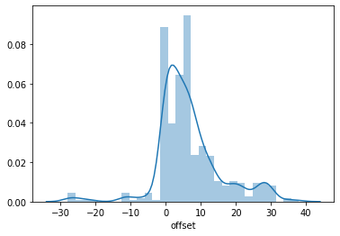

```python
print('Number of X-Rays:', len(df))
print('Number of N/A values for the offset column:', df['offset'].isna().sum())
print('Number of ? values for the offset column:', (df['offset']=='?').sum())
print(f'Datatype of the offset column is {df["offset"].dtype}, but should be an integer')
sns.distplot(df[(df['offset']!='?') & (df['offset']<50)]['offset'])
plt.show()
```

#### Sex

The biological sex of the patient, represented by an M (Male) or F (Female). I will need to convert this to a 1 or 0.

#### Age

The age of the patient, measured in years.

#### Finding

```python
col = 'finding'

print(f'Number of null values in the "{col}" column:', df[col].isna().sum(), '\n')
print(f'Distribution of the "{col}"" column:')

df[col].value_counts()
```

```
Number of null values in the "finding" column: 0

Distribution of the "finding"" column:
```

```
COVID-19                          526
No Finding                         23
Streptococcus                      17
Pneumocystis                       17
SARS                               16
Pneumonia                          14
COVID-19, ARDS                     12
Klebsiella                          8
Mycoplasma Bacterial Pneumonia      8
Legionella                          6
Varicella                           5
Lipoid                              5
ARDS                                4
E.Coli                              4
Bacterial                           4
Chlamydophila                       2
Influenza                           2
Name: finding, dtype: int64
```

#### Survival

Y (Yes) or N (No) or blank if unknown.

```python
col = 'survival'

print(f'Number of null values in the "{col}" column:', df[col].isna().sum(), '\n')
print(f'Distribution of the "{col}" column:')

df[col].value_counts()
```

```
Number of null values in the "survival" column: 409

Distribution of the "survival" column:
```

```
Y    217
N     47
Name: survival, dtype: int64
```

#### Intubated

Whether or not the patient was intubated or ventaliated at any point during the illness. Y (Yes), N (No), or blank if unknown.

```python
col = 'intubated'

print(f'Number of null values in the "{col}" column:', df[col].isna().sum(), '\n')
print(f'Distribution of the "{col}" column:')

df[col].value_counts()
```

```
Number of null values in the "intubated" column: 436

Distribution of the "intubated" column:
```

```
Y    125
N    112
Name: intubated, dtype: int64
```

#### Went_icu

This field is not mentioned in the table schema, but I assume it means:

Y (Yes) if the patient was in the ICU or CCU unit at any point during this illness. I think this would be a Y even if the patient went to an ICU/CCU after the X-Ray but not sure. Blank if unknown.

```python
col = 'went_icu'

print(f'Number of null values in the "{col}" column:', df[col].isna().sum(), '\n')
print(f'Distribution of the "{col}" column:')

df[col].value_counts()
```

```
Number of null values in the "went_icu" column: 377

Distribution of the "went_icu" column:
```

```
Y    185
N    111
Name: went_icu, dtype: int64
```

#### Needed_supplemental_O2

Y (Yes) if the patient required supplemental oxygen at any point during this illness or N (No). Blank if unknown.

It appears this field is not used enough for it to be of use.

```python
col = 'needed_supplemental_O2'

print(f'Number of null values in the "{col}" column:', df[col].isna().sum(), '\n')
print(f'Distribution of the "{col}" column:')

df[col].value_counts()
```

```
Number of null values in the "needed_supplemental_O2" column: 592

Distribution of the "needed_supplemental_O2" column:
```

```
Y    51
N    30
Name: needed_supplemental_O2, dtype: int64
```

#### Extubated

Y (Yes) if the patient was successfully extubated or N (No). Blank if unknown

```python
col = 'extubated'

print(f'Number of null values in the "{col}" column:', df[col].isna().sum(), '\n')
print(f'Distribution of the "{col}" column:')

df[col].value_counts()
```

```
Number of null values in the "extubated" column: 637

Distribution of the "extubated" column:
```

```
Y    26
N    10
Name: extubated, dtype: int64
```

#### Temperature

Temperature of the patient at the time of the X-Ray, measured in Celcius.

```
Number of X-Rays: 673
Number of unknown temperature recordings: 600
Number of temperature recordings above 60 degreed celcius: 1
```

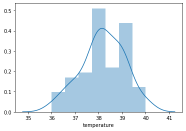

```python
print('Number of X-Rays:', len(df))
print('Number of unknown temperature recordings:', df['temperature'].isna().sum())
print('Number of temperature recordings above 60 degreed celcius:', df[df['temperature']>60].shape[0])

sns.distplot(df[df['temperature']<50]['temperature'])
plt.show()
```

#### pO2_saturation

Partial pressure of oxygen saturation at the time of the X-Ray, measured in %.

```
Number of X-Rays: 673
Number of unknown pO2_saturation recordings: 556
Number of recordings above 100%: 5
```

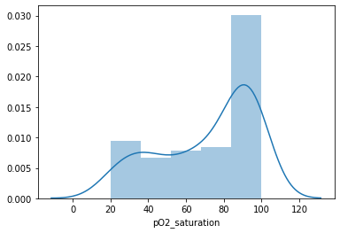

```python
print('Number of X-Rays:', len(df))
print('Number of unknown pO2_saturation recordings:', df['pO2_saturation'].isna().sum())
print('Number of recordings above 100%:', len(df[df['pO2_saturation']>100]))
sns.distplot(df[df['pO2_saturation']<=100]['pO2_saturation'])
plt.show()
```

#### Neutrophil count

Neutrophil cell count at the time of the X-Ray, measure in units of 10^3/uL.

```
Number of X-Rays: 673
Number of null values in the "neutrophil_count" column: 645
```

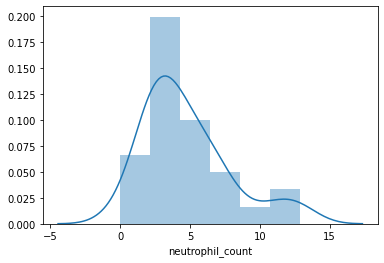

```python
col = 'neutrophil_count'

print('Number of X-Rays:', len(df))
print(f'Number of null values in the "{col}" column:', df[col].isna().sum(), '\n')

sns.distplot(df[col])
plt.show()
```

#### Lymphocyte count

Lymphocyte cell count at the time of the X-Ray, measured in until of 10^3/uL.

```
Number of X-Rays: 673
Number of null values in the "lymphocyte_count" column: 636

Recorded values for this the lymphocyte count field: [  0.9     0.8     1.2     1.3     1.73    0.63    0.8     0.6     0.7
 131.      1.8     1.1     1.      1.6     0.8     1.6     1.2     2.7
   0.4     0.8     1.1     0.6     2.9     1.4     1.3     1.1     1.1
   1.      0.9     2.8     0.5     1.1     1.9     0.6     0.5    10.1
   0.762]
```

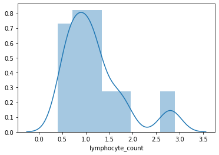

```python
col = 'lymphocyte_count'

print('Number of X-Rays:', len(df))
print(f'Number of null values in the "{col}" column:', df[col].isna().sum(), '\n')

print('Recorded values for this the lymphocyte count field:', df[df[col].isna()==False][col].values)

sns.distplot(df[df[col]<10][col])
plt.show()
```

#### View

PA (Posteranterior), AP (Anteroposterior), or L (Lateral) for X-Rays

Axial or Coronal for CT scans.

How different are these views? Should I train a different model for each type of view?

```python
col = 'view'
print(f'Number of null values in the "{col}" column:', df[col].isna().sum(), '\n')
print(f'Distribution of the "{col}" column:"')
df[col].value_counts()
```

```
Number of null values in the "view" column: 0

Distribution of the "view" column:"
```

```
PA           302
AP Supine    134
AP           106
Axial         68
L             47
Coronal       16
Name: view, dtype: int64
```

#### Modality

X-Ray or CT scan. I will only be using X-Rays.

```python
col = 'modality'
print(f'Number of null values in the "{col}" column:', df[col].isna().sum(), '\n')
print(f'Distribution of the "{col}" column:"')
df[col].value_counts()
```

```
Number of null values in the "modality" column: 0

Distribution of the "modality" column:"
```

```
X-ray    589
CT        84
Name: modality, dtype: int64
```

#### Date

Date the image was acquired. The format of this column varies significantly. Date formats include:

- %B %d, %y
- %b %d, %y
- %y
- %m/%d/%y

```python
col = 'date'

print(f'Datatype of the {col} column is {df[col].dtype}, but should be a datetime')
print(f'Number of null values in the "{col}" column:', df[col].isna().sum(), '\n')
```

```
Datatype of the date column is object, but should be a datetime
Number of null values in the "date" column: 130
```

#### Location

Hospital name, city, state, country.

```python
col = 'location'
print(f'Number of null values in the "{col}" column:', df[col].isna().sum(), '\n')
df[col].value_counts()
```

```
Number of null values in the "location" column: 37
```

```
Hannover Medical School, Hannover, Germany                         92
Italy                                                              81
Spain                                                              24
Humanitas Clinical and Research Hospital, Rozzano, Milan, Italy    20
Melbourne, Australia                                               19
                                                                   ..
The First Hospital of Lanzhou University, Lanzhou, China            1
Argentina                                                           1
Kyiv, Ukraine                                                       1
Macao, China                                                        1
Ospedale di Cattinara, Trieste, Italy                               1
Name: location, Length: 110, dtype: int64
```

#### Folder

The folder that the file is stored in. Either "images" or "volumes".

```python
df['folder'].value_counts()
```

```
images     652
volumes     21
Name: folder, dtype: int64
```

```python
print(len(df[(df.modality=='CT') & (df.folder=='volumes')]))
print(len(df[(df.modality=='CT') & (df.folder=='images')]))
print(len(df[(df.modality=='X-ray') & (df.folder=='images')]))
print(len(df[(df.modality=='X-ray') & (df.folder=='volumes')]))
print(len(df[df.folder=='volumes']))
print(len(df[df.modality=='CT']))
```

```
21
63
589
0
21
84
```

#### Filename

The filename, including the extension.

```python
df['filename'].head()
```

```
0    auntminnie-a-2020_01_28_23_51_6665_2020_01_28_...
1    auntminnie-b-2020_01_28_23_51_6665_2020_01_28_...
2    auntminnie-c-2020_01_28_23_51_6665_2020_01_28_...
3    auntminnie-d-2020_01_28_23_51_6665_2020_01_28_...
4                                nejmc2001573_f1a.jpeg
Name: filename, dtype: object
```

#### DOI

Digital object identifier of the research article.

#### URL

URL of the paper or website where the image came from.

#### License

License of the image.

#### Clinical notes

Clinical notes about the image and/or patient. This column may contain information about the correct label for the image. Notes are often repeated for the same patient, when that patient has had multiple images taken. Notes are sometimes slightly altered with additional information between different images among the same patient.

```python
col = 'clinical_notes'
print(f'Number of null values in the "{col}" column:', df[col].nunique())
print(f'Number of unique entries in the "{col}" column:', df[col].isna().sum())
```

```
Number of null values in the "clinical_notes" column: 443
Number of unique entries in the "clinical_notes" column: 112
```

```python
# some examples of clinical notes
df['clinical_notes'].unique()[:5]
```

```
array(['On January 22, 2020, a 65-year-old man with a history of hypertension, type 2 diabetes, coronary heart disease for which a stent had been implanted, and lung cancer was admitted to the emergency department of Cho Ray Hospital, the referral hospital in Ho Chi Minh City, for low-grade fever an…
       'On January 22, 2020, a 65-year-old man with a history of hypertension, type 2 diabetes, coronary heart disease for which a stent had been implanted, and lung cancer was admitted to the emergency department of Cho Ray Hospital, the referral hospital in Ho Chi Minh City, for low-grade fever an…
       'On January 22, 2020, a 65-year-old man with a history of hypertension, type 2 diabetes, coronary heart disease for which a stent had been implanted, and lung cancer was admitted to the emergency department of Cho Ray Hospital, the referral hospital in Ho Chi Minh City, for low-grade fever an…
       'diffuse infiltrates in the bilateral lower lungs',
       'progressive diffuse interstitial opacities and consolidation in the bilateral parahilar areas and lower lung fields'],
      dtype=object)
```

#### Other Notes

Credit to the people who provided the image.

```python
col = 'other_notes'

print(f'Number of null values in the "{col}" column:', df[col].nunique())
print(f'Number of unique entries in the "{col}" column:', df[col].isna().sum())
```

```
Number of null values in the "other_notes" column: 126
Number of unique entries in the "other_notes" column: 370
```

```python
# some examples of other notes
df['other_notes'].unique()[:5]
```

```
array([nan,
       'Case courtesy of Dr Ali Mashalla hre, Radiopaedia.org, rID: 75037',
       'Case courtesy of Medico Assistente Dr, Chong Keng Sang, Sam, Radiopaedia.org, rID: 73893',
       'Case courtesy of Dr Domenico Nicoletti, Radiopaedia.org, rID: 74724',
       'Case courtesy of Dr Fabio Macori, Radiopaedia.org, rID: 74887'],
      dtype=object)
```

### Display an image in the notebook

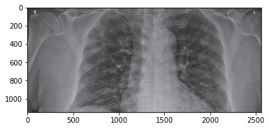

```
Image size: (2563, 1148)
```

```python
# specify the path to the image
sample_img_path = 'covid-chestxray-dataset/images/1-s2.0-S0140673620303706-fx1_lrg.jpg'
# use the load_img method from the image class in Keras
img = image.load_img(sample_img_path)
# plot the image
plt.imshow(img)
plt.show()

# print out the size of the image
print(f'Image size: ({img.width}, {img.height})')
```

Notice the large and irregular image size.

Look into the image sizes and see how much they differ throughout the dataset.

May be enable much faster training if image size is downsampled.

```python
image_size_dict = {
    'filename':[],
    'width':[],
    'height':[]
}

image_paths = glob.glob('covid-chestxray-dataset/images/*.jpg')

for img_path in image_paths:
    img = image.load_img(img_path)

    image_size_dict['filename'].append(os.path.basename(img_path))
    image_size_dict['width'].append(img.width)
    image_size_dict['height'].append(img.height)

image_size_df = pd.DataFrame(image_size_dict)
```

#### Images can be different sizes

```python
print(image_size_df.nunique())

image_size_df.head()
```

```
filename    344
width       193
height      188
dtype: int64
```

|  | filename | width | height |
| --- | --- | --- | --- |
| 0 | 8da14fff.jpg | 2000 | 2000 |
| 1 | b9673e89.jpg | 2000 | 2000 |
| 2 | pneumococcal-pneumonia-day7.jpg | 2828 | 2320 |
| 3 | 16630_6_1.jpg | 1549 | 1059 |
| 4 | kjr-21-e24-g002-l-a.jpg | 298 | 294 |

#### Get an idea of what size I should reshape the images to based on the smaller image sizes

```python
image_size_df[['width', 'height']].min()
```

```
width     287
height    237
dtype: int64
```

#### The width and height of the photos can vary significantly

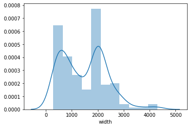

```python
sns.distplot(image_size_df['width'])
plt.show()
```

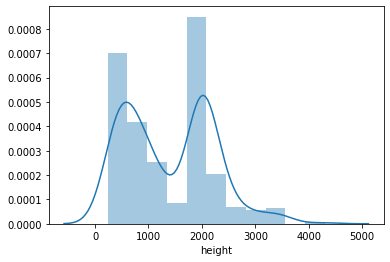

```python
sns.distplot(image_size_df['height'])
plt.show()
```

### Filter images

#### Compile a list of filepaths to images that I want to include in the dataset. Don't include more than one image per patient.

Use the most recent image from each patient

```python
pd.set_option('max_colwidth', 1000)

# data is sorted by date in ascending order, so I don't need to re-sort by date
metadata = df[df['modality']=='X-ray']

# only include the most recent image for each patient
metadata.drop_duplicates('patientid', keep='last', ignore_index=True, inplace=True)

metadata[['folder', 'filename']].head()
```

|  | folder | filename |
| --- | --- | --- |
| 0 | images | auntminnie-d-2020_01_28_23_51_6665_2020_01_28_Vietnam_coronavirus.jpeg |
| 1 | images | nejmc2001573_f1b.jpeg |
| 2 | images | ARDSSevere.png |
| 3 | images | lancet-case2b.jpg |
| 4 | images | SARS-10.1148rg.242035193-g04mr34g0-Fig8c-day10.jpeg |

#### Create a "filepath" column containing the filepaths to all the images. Use the most recent image for each patient.

```python
metadata['filepath'] = 'covid-chestxray-dataset/' + metadata['folder'] + '/' + metadata['filename']

metadata['filepath'].head()
```

```
0    covid-chestxray-dataset/images/auntminnie-d-2020_01_28_23_51_6665_2020_01_28_Vietnam_coronavirus.jpeg
1                                                     covid-chestxray-dataset/images/nejmc2001573_f1b.jpeg
2                                                            covid-chestxray-dataset/images/ARDSSevere.png
3                                                         covid-chestxray-dataset/images/lancet-case2b.jpg
4                       covid-chestxray-dataset/images/SARS-10.1148rg.242035193-g04mr34g0-Fig8c-day10.jpeg
Name: filepath, dtype: object
```

### Resize images

#### Load the images into a numpy array and transform them so each image has the same width and height

```python
import cv2 # OpenCV to resize the images

width = 200
height = 200

# .convert(mode='L') converts from 3 channel to 2 channel
# pixel intensity ranges from 0 to 255. Scale from 0 to 1 by dividing by 255
data = np.array([cv2.resize(np.array(Image.open(image).convert(mode='L'))/255, (width, height)) for image in image_filepaths]).reshape(-1, width, height, 1)

print(data.shape)
```

```
(319, 200, 200, 1)
```

```python
data.shape
```

```
(319, 200, 200, 1)
```

#### Verify the images look right and have correct size after the channel transformation and resizing.

```
(200, 200, 1)
```

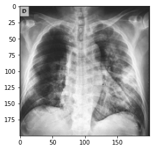

```
(200, 200, 1)
```

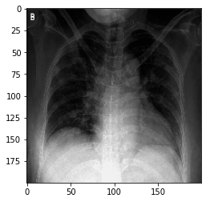

```
(200, 200, 1)
```

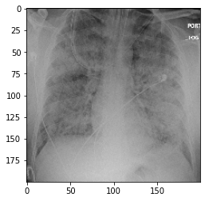

```
(200, 200, 1)
```

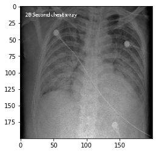

```
(200, 200, 1)
```

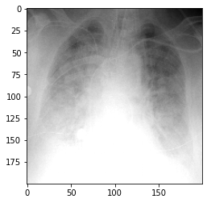

```python
for i in range(5):
    print(data[i].shape)
    plt.imshow(data[i, :, :, 0], cmap='gray')
    plt.show()
```

### Prepare target variable

#### It looks like nearly all of the X-Ray images are of lungs with a patient with a disease. It's usually a respiratory disease.

If "No Finding" indicates that the patient was healthy, there are only 11 example images of healthy lungs.

```python
metadata['finding'].value_counts()
```

[output not shown]

#### Create a y vector where an element equals 1 if the patient had COVID-19, else let the element equal 0.

```python
# print(metadata['filepath'].values[:5])
# print(image_paths[:5])

image_filepaths = metadata['filepath'].values
y = np.where(metadata['finding'].str.contains('COVID-19'), 1, 0)
```

#### Now I have 319 samples of 200 by 200 images

```python
print(data.shape)
```

```
(319, 200, 200, 1)
```

### Split into train/val/test

60% of the training data will go into the training set, 20% into the validation set, and 20% into the test set.

```python
from sklearn.model_selection import train_test_split

X_train, X_test, y_train, y_test = train_test_split(data, y, test_size=0.2, random_state=1)
X_train, X_val, y_train, y_val, = train_test_split(X_train, y_train, test_size=0.25)
```

#### Create directories for these subsets of data and save as .npy files into the EBS volume this notebook uses. I will have to specify these directories when launching a training job.

Also, compute class weights to use during training to account for the class imbalance. I have more examples of images of lungs of patients with COVID-19 than non-COVID diseases.

```python
from sklearn.utils.class_weight import compute_class_weight
import os

data_dir = os.path.join(os.getcwd(), 'data')
os.makedirs(data_dir, exist_ok=True)

train_dir = os.path.join(os.getcwd(), 'data/train')
os.makedirs(train_dir, exist_ok=True)

test_dir = os.path.join(os.getcwd(), 'data/test')
os.makedirs(test_dir, exist_ok=True)

val_dir = os.path.join(os.getcwd(), 'data/val')
os.makedirs(val_dir, exist_ok=True)

class_weights = compute_class_weight(class_weight='balanced', classes=[0,1], y=y_train)
class_weights_dir = os.path.join(os.getcwd(), 'data/classweights')
os.makedirs(class_weights_dir, exist_ok=True)

np.save(os.path.join(class_weights_dir, 'classweights.npy'), class_weights)

np.save(os.path.join(train_dir, 'X_train.npy'), X_train)
np.save(os.path.join(val_dir, 'X_val.npy'), X_val)
np.save(os.path.join(test_dir, 'X_test.npy'), X_test)
np.save(os.path.join(train_dir, 'y_train.npy'), y_train)
np.save(os.path.join(val_dir, 'y_val.npy'), y_val)
np.save(os.path.join(test_dir, 'y_test.npy'), y_test)
```

```python
print(class_weights)
```

```
[2.984375   0.60062893]
```

### Local Training

To train in local mode, we need a docker-compose or nvidia-docker-compose. Download with the following commands:

```python
!wget -q https://raw.githubusercontent.com/aws-samples/amazon-sagemaker-script-mode/master/local_mode_setup.sh
!wget -q https://raw.githubusercontent.com/aws-samples/amazon-sagemaker-script-mode/master/daemon.json
!/bin/bash ./local_mode_setup.sh
```

```
SageMaker instance route table setup is ok. We are good to go.
SageMaker instance routing for Docker is ok. We are good to go!
```

- Create the local_estimator object.
- Specify the GitHub repo where I store the code the defines the model architecture and the training script.
- Tell the local estimator to save the model to '/opt/ml/model' on this notebook's EBS volume.
- Also, specify the hyperparameters to use for this training job. My training script accepts the hyperparameters: epochs, batch_size, and learning_rate.

```python
from sagemaker.tensorflow import TensorFlow
import sagemaker

# git repo that contains train.py and model_def.py files.
git_config = {'repo': 'https://github.com/DanOKeefe/COVID-19_X-Ray_Classification',
              'branch': 'master'}

model_dir = '/opt/ml/model'

train_instance_type = 'local'
hyperparameters = {'epochs': 5, 'batch_size':8, 'learning_rate':0.01}
local_estimator = TensorFlow(git_config=git_config,
                             source_dir='',
                             entry_point='train.py',
                             model_dir=model_dir,
                             train_instance_type=train_instance_type,
                             train_instance_count=1,
                             hyperparameters=hyperparameters,
                             role=sagemaker.get_execution_role(),
                             base_job_name='covid-19_x-ray_classification',
                             framework_version='2.1',
                             py_version='py3',
                             script_mode=True)
```

- Tell the estimator where to find the data for the training set, test set, and class weights to use

```python
inputs = {'train': f'file://{train_dir}',
         'test': f'file://{test_dir}',
         'class_weights': f'file://{class_weights_dir}'}

local_estimator.fit(inputs, logs=False)
```

```
'create_image_uri' will be deprecated in favor of 'ImageURIProvider' class in SageMaker Python SDK v2.
```

[output not shown]

[output cut: 80 more lines]

[output not shown]

#### Deploy a Local Mode endpoint for inference

```python
local_predictor = local_estimator.deploy(initial_instance_count=1, instance_type='local')
```

```
Parameter image will be renamed to image_uri in SageMaker Python SDK v2.
'create_image_uri' will be deprecated in favor of 'ImageURIProvider' class in SageMaker Python SDK v2.
```

[output not shown]

[output cut: 70 more lines]

[output not shown]

#### Retrieve some predictions from the endpoint

```python
local_results = local_predictor.predict(X_test[:10])['predictions']
```

```
algo-1-55k36_1  | 172.18.0.1 - - [31/Jul/2020:20:08:12 +0000] "POST /invocations HTTP/1.1" 200 178 "-" "-"
```

```python
local_predictor.delete_endpoint()
```

```
Gracefully stopping... (press Ctrl+C again to force)
```

```python
print(local_results)
```

```
[[0.791430831], [0.787747204], [0.713230252], [0.797583699], [0.799459279], [0.562074065], [0.690957725], [0.560378075], [0.718893766], [0.716952145]]
```

```python
y_test[:10]
```

```
array([1, 1, 1, 1, 1, 0, 1, 0, 1, 1])
```

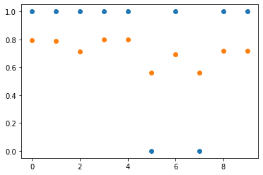

```python
plt.scatter(range(10), y_test[:10])
plt.scatter(range(10), local_results)
plt.show()
```

If I were to use the locally trained model, I would guess a threshold of around 0.6 would work best based on what I see from the above graph. This would properly classify all the 10 datapoints in this example. However, this would have a high probability of changing as I train with more data and tune other hyperparameters.

### SageMaker Hosted Training

Put the data needed for training and validation into s3 buckets. The hosted training job will retrieve the data from these S3 buckets.

For **local training**, the data needs to be split into different directories on the notebook's EBS volume. For **hosted training**, the data needs to be split into different directories in an S3 bucket.

```python
s3_prefix = 'covid19-xray'
traindata_s3_prefix = '{}/data/train'.format(s3_prefix)
testdata_s3_prefix = '{}/data/test'.format(s3_prefix)
classweights_s3_prefix = '{}/data/classweights'.format(s3_prefix)
```

```python
train_s3 = sess.upload_data(path='./data/train/', key_prefix=traindata_s3_prefix)
test_s3 = sess.upload_data(path='./data/test/', key_prefix=testdata_s3_prefix)
classweights_s3 = sess.upload_data(path='./data/classweights/', key_prefix=classweights_s3_prefix)

inputs = {'train':train_s3, 'test':test_s3, 'class_weights':classweights_s3}

print(inputs)
```

```
{'train': 's3://sagemaker-us-west-2-333168375027/covid19-xray/data/train', 'test': 's3://sagemaker-us-west-2-333168375027/covid19-xray/data/test', 'class_weights': 's3://sagemaker-us-west-2-333168375027/covid19-xray/data/classweights'}
```

```python
# choose a training instance type
train_instance_type = 'ml.c5.xlarge'
# define the hyperparameters for this training job.
hyperparameters = {'epochs': 20, 'batch_size': 8, 'learning_rate': 0.01}

# create the estimator object.
estimator = TensorFlow(git_config=git_config,
                       source_dir = '',
                       entry_point='train.py',
                       model_dir=model_dir,
                       train_instance_type=train_instance_type,
                       train_instance_count=1,
                       hyperparameters=hyperparameters,
                       role=sagemaker.get_execution_role(),
                       base_job_name='covid-19-x-ray-classification',
                       framework_version='2.1',
                       py_version='py3',
                       script_mode=True)
```

#### Execute the hosted training job

```python
estimator.fit(inputs)
```

#### Copy the resulting trained model from S3 to the SageMaker EBS volume.

```python
!aws s3 cp {estimator.model_data} ./model/model.tar.gz
```

```
download: s3://sagemaker-us-west-2-333168375027/covid-19-x-ray-classification-2020-07-31-22-11-53-212/output/model.tar.gz to model/model.tar.gz
```

```python
!tar -xvzf ./model/model.tar.gz -C ./model
```

```
1/
1/variables/
1/variables/variables.data-00000-of-00001
1/variables/variables.index
1/saved_model.pb
1/assets/
```

### Hyperparameter Tuning Job

- Define which parameters to tune, along with bounds of possible values to choose from.
- Specify the objective is to minimize validation loss

```python
from sagemaker.tuner import IntegerParameter, CategoricalParameter, ContinuousParameter, HyperparameterTuner

hyperparameter_ranges = {
    'learning_rate': ContinuousParameter(0.001, 0.2, scaling_type='Logarithmic'),
    'epochs': IntegerParameter(16, 64),
    'batch_size': IntegerParameter(4, 16)
}

metric_definitions = [{'Name': 'loss',
                       'Regex': ' loss: ([0-9\\.]+)'},
                     {'Name': 'val_loss',
                       'Regex': ' val_loss: ([0-9\\.]+)'}]

objective_metric_name = 'val_loss'
objective_type = 'Minimize'
```

#### Create the tuner and start the tuning job

```python
# HyperparameterTuner is a class for creating and interacting with Amazon SageMaker hyperparameter tuning jobs
# as well as deploying the resulting models.
tuner = HyperparameterTuner(estimator,
                            objective_metric_name,
                            hyperparameter_ranges,
                            metric_definitions,
                            max_jobs=6,
                            max_parallel_jobs=3,
                            objective_type=objective_type)
tuning_job_name = 'covid19-xray-{}'.format(strftime('%d-%H-%M-%S', gmtime()))
tuner.fit(inputs, job_name=tuning_job_name)
tuner.wait()
```

```
's3_input' class will be renamed to 'TrainingInput' in SageMaker Python SDK v2.
's3_input' class will be renamed to 'TrainingInput' in SageMaker Python SDK v2.
's3_input' class will be renamed to 'TrainingInput' in SageMaker Python SDK v2.
'create_image_uri' will be deprecated in favor of 'ImageURIProvider' class in SageMaker Python SDK v2.
```

[output not shown]

```python
tuner_metrics = sagemaker.HyperparameterTuningJobAnalytics(tuning_job_name)
tuner_metrics.dataframe()['TrainingJobStatus'].value_counts()
```

```
Completed    6
Name: TrainingJobStatus, dtype: int64
```

#### Billable hours of training time this job took:

```python
total_time = tuner_metrics.dataframe()['TrainingElapsedTimeSeconds'].sum() / 3600
print('Total training time was {:2f} hours'.format(total_time))
tuner_metrics.dataframe()['TrainingJobStatus'].value_counts()
```

```
Total training time was 0.789722 hours
```

```
Completed    6
Name: TrainingJobStatus, dtype: int64
```

#### Deploy tuned model to a SageMaker endpoint

```python
# check if there is an argument in the tuner.deploy() method that reduces the amount of info printed out during tuning.
tuning_predictor = tuner.deploy(initial_instance_count=1, instance_type='ml.t2.medium')
```

#### Run the first 10 examples through the models that were trained during this hyperparameter tuning job.

- Print out the predictions vs actual values

```python
results = tuning_predictor.predict(X_test[:10])['predictions']
flat_list = [float('%.1f'%(item)) for sublist in results for item in sublist]
print('predictions: \t{}'.format(np.array(flat_list)))
print('target values: \t{}'.format(y_test[:10].round(decimals=1)))
```

```
predictions: 	[0.8 0.9 0.8 0.8 0.9 0.2 0.9 0.5 0.8 0.9]
target values: 	[1 1 1 1 1 0 1 0 1 1]
```

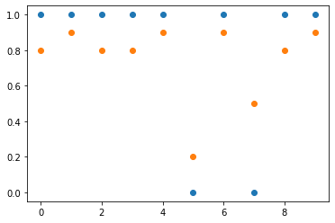

```python
plt.scatter(range(10), y_test[:10])
plt.scatter(range(10), flat_list)
plt.show()
```

#### Delete the endpoint that hosted the tuning job to avoid over-billing

```python
sess.delete_endpoint(tuning_predictor.endpoint)
```

#### Go into the AWS console > Sagemaker > Training > "Hyperparameter tuning jobs" to find which tuning job yielded the best results.

- Record those hyperparameters to use in the production-level model

```python
best_hyperparameter_tuning_job_name = 'covid19-xray-15-22-23-27-004-6aee03ce'
# batch size: 6
# epochs: 51
# learning rate: 0.0414
```